# Administrative Justice and Regime Support in Kazakhstan: How Institutional Remedies Shape Citizen Perceptions

Alisher Juzgenbayev

Northwestern University  
Department of Political Science / Pritzker School of Law

## Puzzle: Citizenship Engagement and Complaints

2012-2025, 210,000 cleaned question-answer pairs:

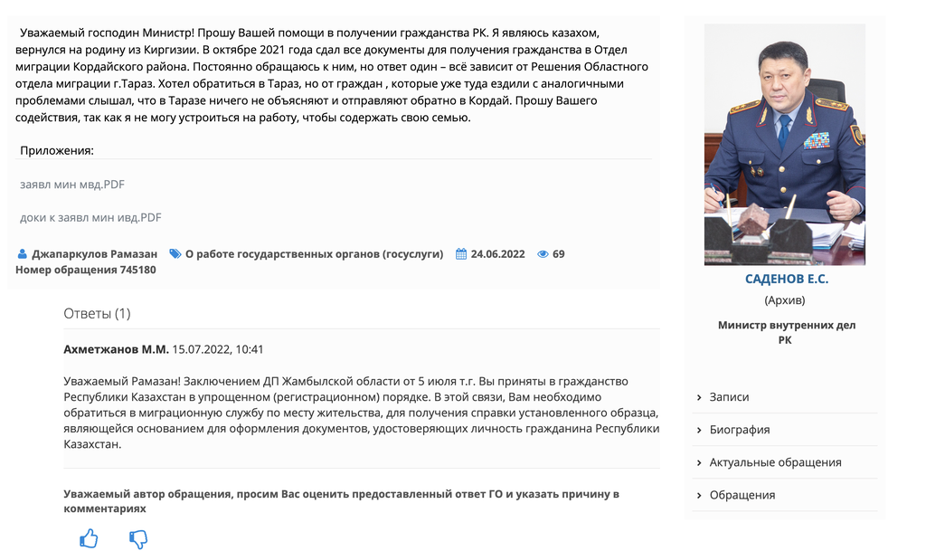

## Complaint Volume Over Time

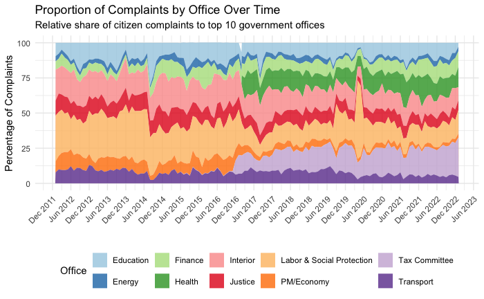

Complaints Received by Key Offices Over Time

## Complaint Framing by Citizens

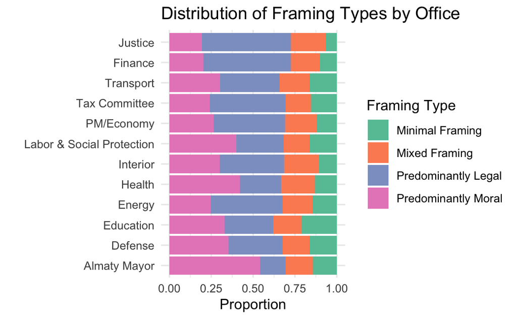

Prevalence of Legal vs. Moral Framing in Complaints

## Office Responsiveness

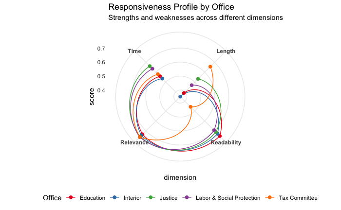

Radar Plot Illustrating a Profile (e.g., Office Responsiveness)

## Focus on Administrative Justice

Themes: Material disputes (entitlements, social benefits, education and health care); Mix of legalistic & moral/plea-based language in complaints; Largely standardized, bureaucratic responses.

How does the State manage this volume of complaints?

- **Administrative Justice System**: Key arena for citizen-state interaction.
- In Post-Soviet countries, hybrid systems, e.g., Procuracy, specialized administrative courts, ombudsmen, tradition of complaints (Bogdanova, 2021), courts of general jurisdiction (Hendley, 2023), etc.
- Focus: The *administrative-justice* system in a dual state. See Hendley, 2022; Sakwa, 2010; Trochev & Solomon, 2018.

## Two Modes of Administrative Justice (Kagan 2001)

### 1. Bureaucratic-Managerial

- **Example**: **Procuracy**, internal review.
- **Logic**: Hierarchical error-correction.
  - Information for rulers.
  - Limits claimant power.
- **Kagan**: *Bureaucratic Legalism*.

### 2. Legal-Rights

- **Example**: Administrative courts.
- **Logic**: Adversarial, individual entitlements.
  - Advertises legal boundedness.
  - International legitimacy.
- **Kagan**: *Adversarial Legalism*.

Coexisting modes => Different experiences => Potentially different impacts.

## Linking Institutions to Attitudes

- **Choosing Where to Turn**
  - Institutional encounters and structural position (Sandefur, 2008)
  - Political participation and legal culture (Hilbink, 2022; 2024)
  - Perceptions of likelihood of success (Hendley, 2017)
- **Effects of the Encounter**
  - State/Regime legitimacy perceptions (Whiting, 2017)
  - Trust in courts or legal system (Hendley, 2015; Gallagher, 2006)
  - Internal efficacy (Gallagher, 2011)

Prior work links resources, ideology, and past experiences to whether people complain and to the effects of legal encounters, but less often distinguishes which institution citizens confront.

## Research Questions

Activation – Who chooses which administrative‑justice institution, and are these choices linked to distinct conceptions of rights?

Consequences – How do encounters with the procuracy versus administrative courts shape trust, rights consciousness, and future mobilisation?

Proposed: Two-step vignette experiment (national online survey, Kazakhstan).

## Survey Experiment: Design

1. **Grievance Stage (Manipulation 1)**:
   - Common grievance (e.g., unpaid benefit).
   - **Random Assignment**: Wrongdoer = **State Agency** OR **Private Employer**.
2. **Resolution Stage (Manipulation 2)**:
   - Grievance resolved favorably.
   - **Random Assignment**: Resolution via **Administrative Court** OR **Procuracy**.

## Vignette Example: Step 1 (Grievance)

**State Actor Vignette**:

> “Imagine… When calculating your unemployment social payment, **the state agency** incorrectly determined the average monthly income… your monthly unemployment benefit is 25,000 tenge less than it should be by law… Agency staff tell you the calculation was done according to their standard procedure.”

**Private Actor Vignette**:

> “Imagine… When calculating your monthly sales commission, **your employer** incorrectly calculated the sales period… your monthly commission is 25,000 tenge less than it should be under your employment contract… The company’s accounting department tells you the calculation was done according to their standard procedure.”

**Post-Vignette 1 Measures**: Problem label, preferred venue, expected effectiveness of Court vs. Procuracy.

## Vignette Example: Step 2 (Resolution)

**Court Resolution Vignette**:

> “Following your complaint, your case was heard in the administrative court… the judge ruled in your favor… The court found that **[the agency/company]** had violated your legal rights and ordered them to recalculate. The judge emphasized that everyone is entitled to fair treatment under the law… The court’s decision referenced specific … law regulations…”

**Procuracy Resolution Vignette**:

> “Following your complaint, your case was reviewed by the local prosecutor’s office… the prosecutor determined that **[the agency/company]** had not followed proper procedures… **[the agency/company]** was instructed to recalculate. The prosecutor emphasized that everyone is entitled to fair treatment under the law… The prosecutor’s decision referenced specific … law regulations…”

**Post-Vignette 2 Measures**: Satisfaction, fairness, trust (courts, prosecutors, government), state “bound by law,” sense of rights.

## Key Hypotheses

- **H1 (Framing)**: State disputes → “rights violations.”
- **H2 (Preference)**: “Rights” framing → court preference.
- **H3 (Fairness)**: Procuracy certain, but courts procedurally “fairer.”
- **H4 (Attitudes)**:
  - **Courts**: ↑ State legitimacy (may ↓ regime confidence).
  - **Procuracy**: ↑ State legitimacy/trust (↑ regime confidence).
- **H5/H6 (Moderators)**: Education, income, etc.

## Thank you!

**Alisher Juzgenbayev**  
alisher.juzgenbayev@law.northwestern.edu